# Endterm Project - UK Big Data und Uncertainty Quantification

Lorenz Dick und David Gorbach

2026-02-08

The following data analysis has the goal of choosing the best model to determine whether a person was approved to receive a bank loan or not. We used the following models to examine the data: logistic regression, decision tree, bagging, random forest, linear discriminant analysis, k nearest neighbors, and support vector classification.

# Exploratory Data Analysis

```r
data <- read.csv("bankloan.csv")
data <- data[,-1]
dim(data)
```

```
## [1] 5000   13
```

The data set consists of 5000 observation of 13 Variables.

Variables:

- Age : Customer Age
- Experience : Customer Experience
- Income : Income of the Customer
- ZipCode: Customer’s residence zipcode
- Family : No of Family members of the customer
- CCAvg: Credit Card Average Score
- Education: Education of the customer

```r
kable(head(data))
```

| Age | Experience | Income | ZIP.Code | Family | CCAvg | Education | Mortgage | Personal.Loan | Securities.Account | CD.Account | Online | CreditCard |
| --- | --- | --- | --- | --- | --- | --- | --- | --- | --- | --- | --- | --- |
| 25 | 1 | 49 | 91107 | 4 | 1.6 | 1 | 0 | 0 | 1 | 0 | 0 | 0 |
| 45 | 19 | 34 | 90089 | 3 | 1.5 | 1 | 0 | 0 | 1 | 0 | 0 | 0 |
| 39 | 15 | 11 | 94720 | 1 | 1.0 | 1 | 0 | 0 | 0 | 0 | 0 | 0 |
| 35 | 9 | 100 | 94112 | 1 | 2.7 | 2 | 0 | 0 | 0 | 0 | 0 | 0 |
| 35 | 8 | 45 | 91330 | 4 | 1.0 | 2 | 0 | 0 | 0 | 0 | 0 | 1 |
| 37 | 13 | 29 | 92121 | 4 | 0.4 | 2 | 155 | 0 | 0 | 0 | 1 | 0 |

```r
any(is.na(data))
```

```
## [1] FALSE
```

We don’t have NA’s in our data.

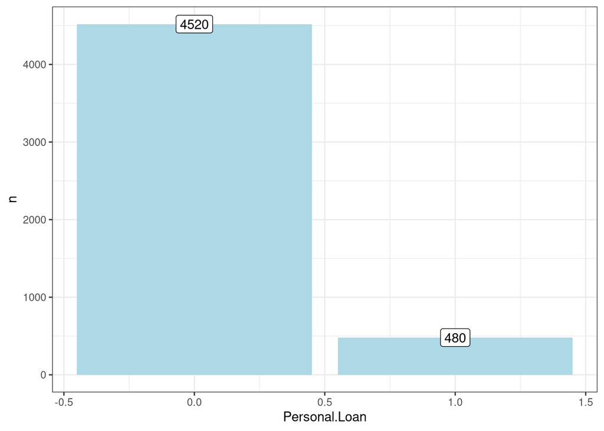

```r
data %>%
  group_by(Personal.Loan) %>%
  summarise(n=n()) %>%
  ggplot(aes(x=Personal.Loan, y = n)) +
  geom_bar(stat = "identity", fill="lightblue") +
  geom_label(aes(label = n))
```

```r
tab[2]/sum(tab)
```

```
##     1
## 0.096
```

We see that loans were only given in ~10% of cases.

Info about categorical predictors:

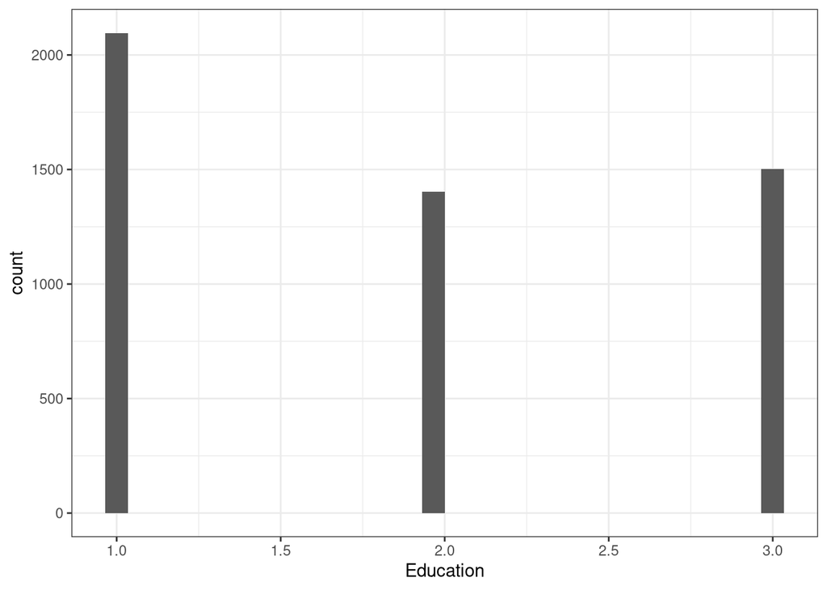

```r
ggplot(data=data, aes(x=Education)) + geom_histogram()
```

Education has only three values.

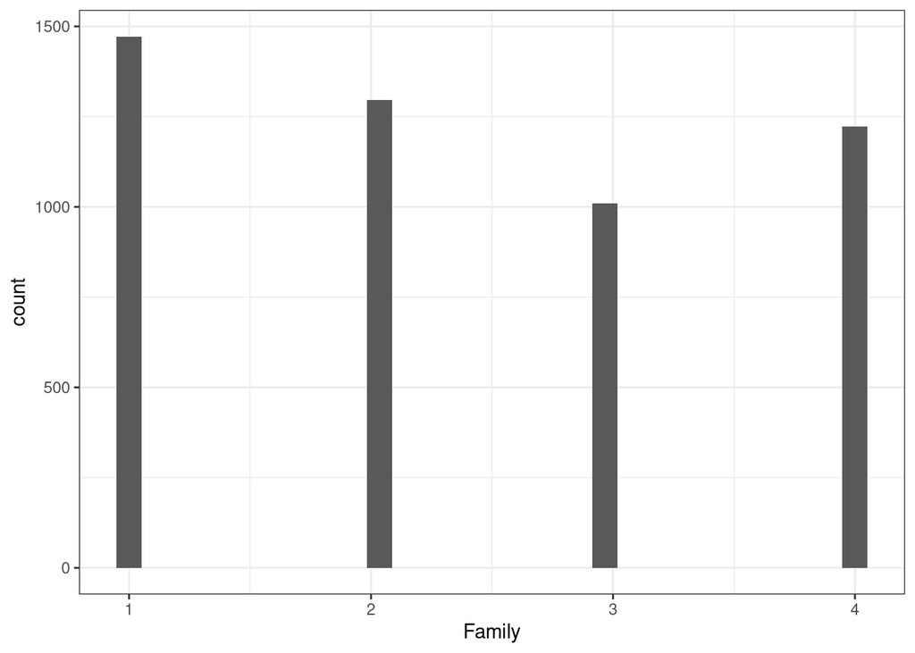

```r
ggplot(data=data, aes(x=Family)) + geom_histogram()
```

The number of family members is at most 4.

Since these are ordinal, we chose to treat them as numerical variables nevertheless.

```r
skim(data)
```

Data summary

| Name | data |
| --- | --- |
| Number of rows | 5000 |
| Number of columns | 13 |
| _______________________ |  |
| Column type frequency: |  |
| numeric | 13 |
| ________________________ |  |
| Group variables | None |

**Variable type: numeric**

| skim_variable | n_missing | complete_rate | mean | sd | p0 | p25 | p50 | p75 | p100 | hist |
| --- | --- | --- | --- | --- | --- | --- | --- | --- | --- | --- |
| Age | 0 | 1 | 45.34 | 11.46 | 23 | 35.0 | 45.0 | 55.0 | 67 | ▅▇▇▇▆ |
| Experience | 0 | 1 | 20.10 | 11.47 | -3 | 10.0 | 20.0 | 30.0 | 43 | ▅▇▇▇▅ |
| Income | 0 | 1 | 73.77 | 46.03 | 8 | 39.0 | 64.0 | 98.0 | 224 | ▇▇▃▂▁ |
| ZIP.Code | 0 | 1 | 93152.50 | 2121.85 | 9307 | 91911.0 | 93437.0 | 94608.0 | 96651 | ▁▁▁▁▇ |
| Family | 0 | 1 | 2.40 | 1.15 | 1 | 1.0 | 2.0 | 3.0 | 4 | ▇▇▁▆▆ |
| CCAvg | 0 | 1 | 1.94 | 1.75 | 0 | 0.7 | 1.5 | 2.5 | 10 | ▇▃▁▁▁ |
| Education | 0 | 1 | 1.88 | 0.84 | 1 | 1.0 | 2.0 | 3.0 | 3 | ▇▁▆▁▆ |
| Mortgage | 0 | 1 | 56.50 | 101.71 | 0 | 0.0 | 0.0 | 101.0 | 635 | ▇▂▁▁▁ |
| Personal.Loan | 0 | 1 | 0.10 | 0.29 | 0 | 0.0 | 0.0 | 0.0 | 1 | ▇▁▁▁▁ |
| Securities.Account | 0 | 1 | 0.10 | 0.31 | 0 | 0.0 | 0.0 | 0.0 | 1 | ▇▁▁▁▁ |
| CD.Account | 0 | 1 | 0.06 | 0.24 | 0 | 0.0 | 0.0 | 0.0 | 1 | ▇▁▁▁▁ |
| Online | 0 | 1 | 0.60 | 0.49 | 0 | 0.0 | 1.0 | 1.0 | 1 | ▆▁▁▁▇ |
| CreditCard | 0 | 1 | 0.29 | 0.46 | 0 | 0.0 | 0.0 | 1.0 | 1 | ▇▁▁▁▃ |

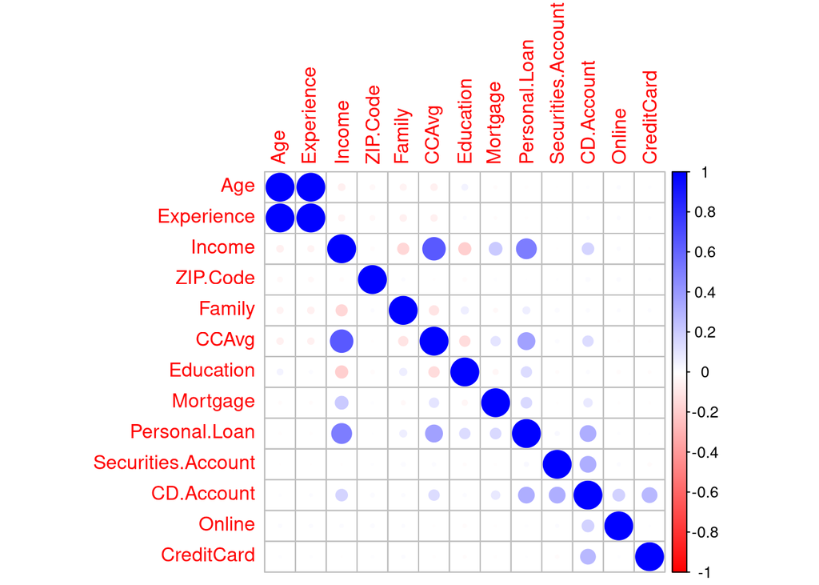

```r
corrplot(
  cor(data),
  method = "circle",
  col = colorRampPalette(c("red", "white", "blue"))(200),
  tl.col = "red",
  tl.srt = 90,
  addCoef.col = NULL,
  number.cex = 0.7,
  diag = TRUE
)
```

The largest correlations with Personal Loan are with Income, average Credit, and CD Account. Slighter correlation with Education, Mortgage and Family.

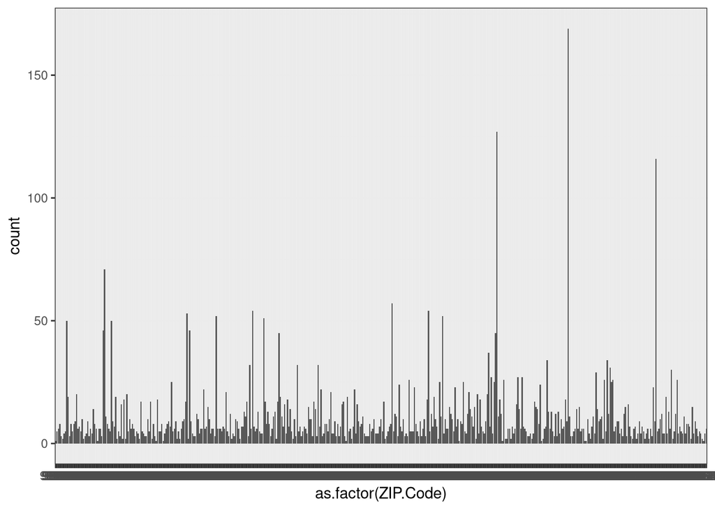

```r
ggplot(data, aes(x = as.factor(ZIP.Code))) + geom_bar()
```

There are too many zip codes (categories) to make sense of it as a predictor. We therefore exclude it from our analysis. We convert Personal.Loan to factor. All predictor variables are ordinal and will therefore be treated as numerical variables.

```r
data <- data %>% dplyr::select(!ZIP.Code) %>%
  mutate(Personal.Loan = as.factor(Personal.Loan))
```

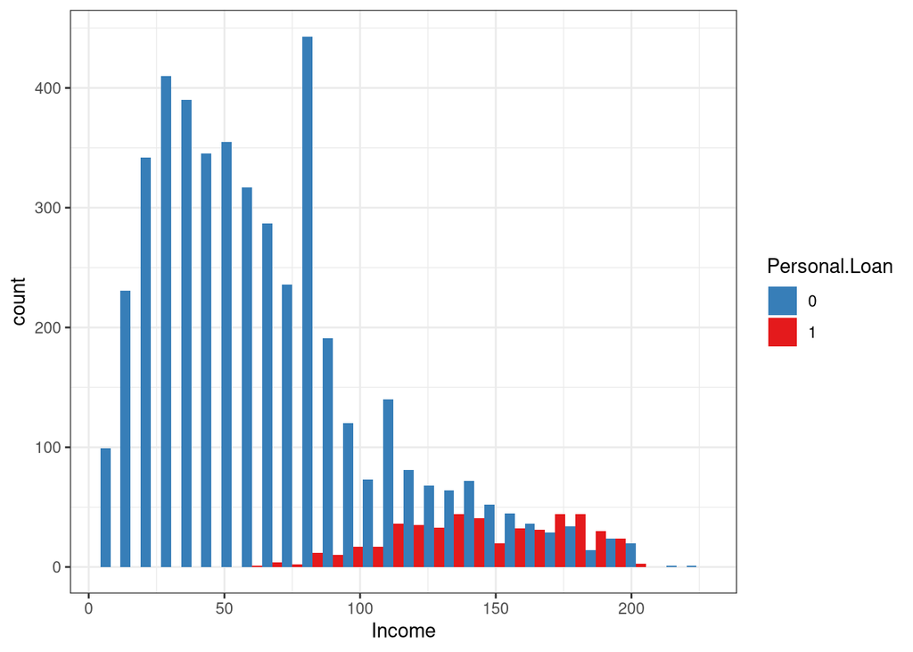

```r
ggplot(data,
  aes ( x= Income, fill = Personal.Loan)) +
  geom_histogram(position = "dodge")+
  scale_fill_brewer( palette =  "Set1", direction =-1)
```

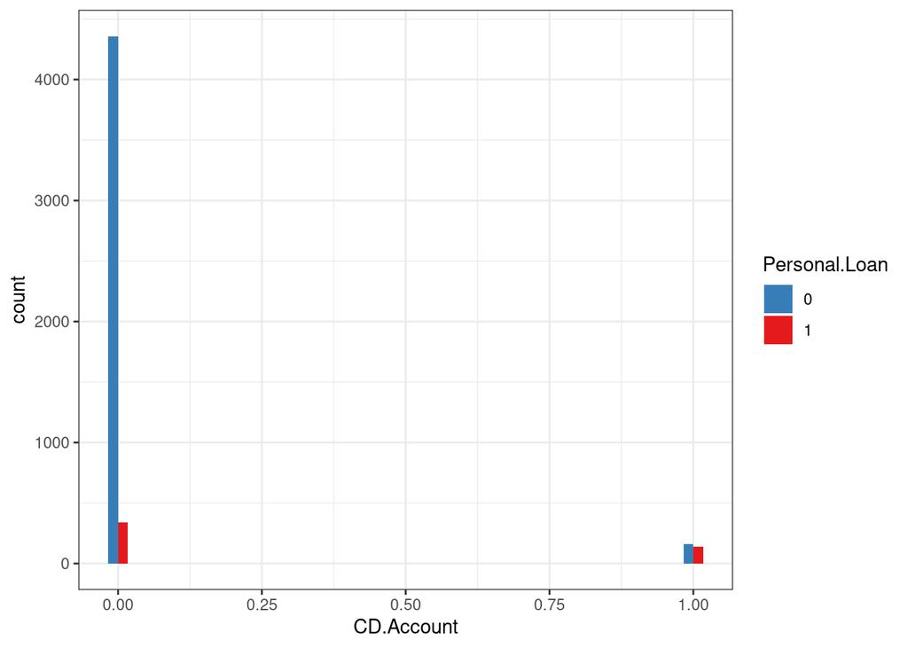

```r
ggplot(data,
  aes ( x= CD.Account, fill = Personal.Loan)) +
  geom_histogram(position = "dodge")+
  scale_fill_brewer( palette =  "Set1", direction =-1)
```

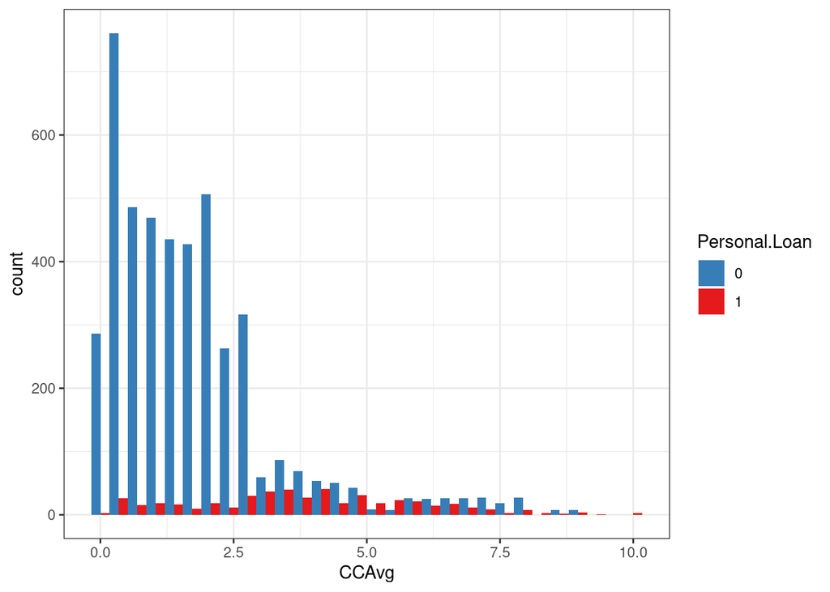

```r
ggplot(data,
  aes ( x= CCAvg, fill =Personal.Loan)) +
  geom_histogram(position = "dodge")+
  scale_fill_brewer( palette =  "Set1", direction =-1)
```

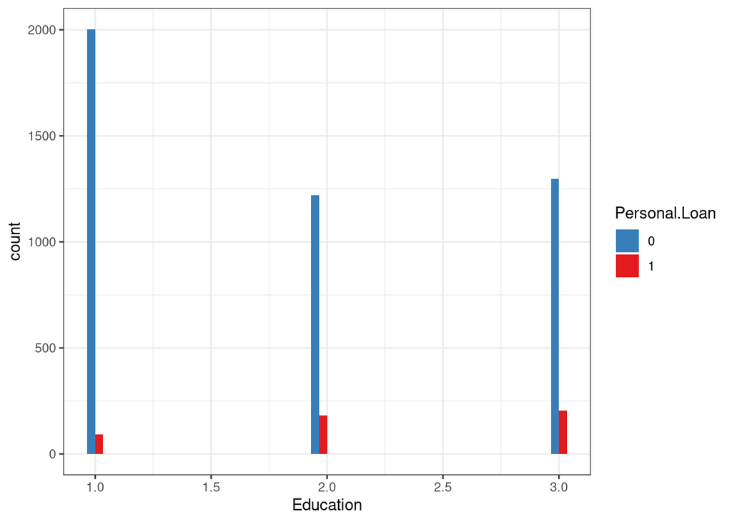

```r
ggplot(data,
  aes ( x= Education, fill = Personal.Loan)) +
  geom_histogram(position = "dodge")+
  scale_fill_brewer( palette =  "Set1", direction =-1)
```

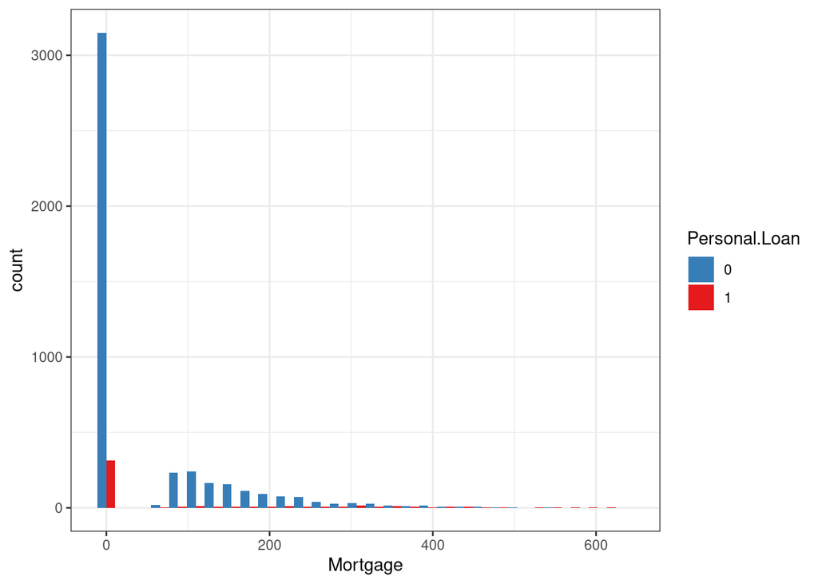

```r
ggplot(data,
  aes ( x= Mortgage, fill = Personal.Loan)) +
  geom_histogram(position = "dodge")+
  scale_fill_brewer( palette =  "Set1", direction =-1)
```

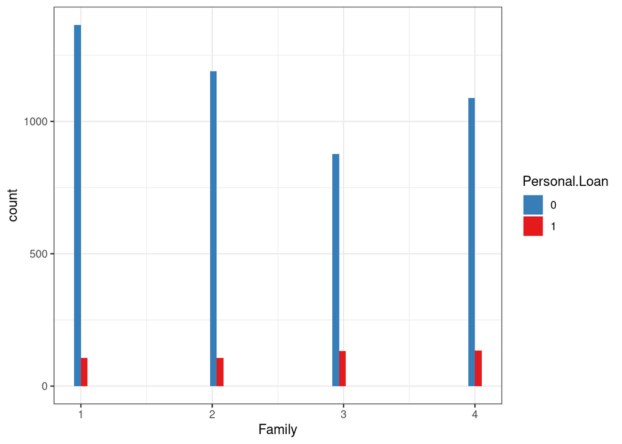

```r
ggplot(data,
  aes ( x= Family, fill = Personal.Loan)) +
  geom_histogram(position = "dodge")+
  scale_fill_brewer( palette =  "Set1", direction =-1)
```

Income and Credit Card Average Score seam to have a high influence on whether a loan is granted or not. The distribution of Credit Score Averages is rather uniformly among people who received a loan, though among those with a higher avarage had a much bigger chance of receiving a loan. Both higher education and higher family had a slight higer change of receiving a loan.

Check for outliers:

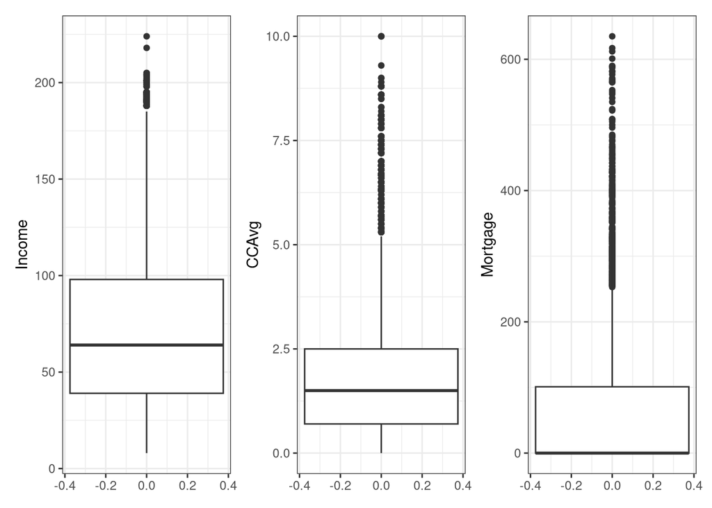

```r
out1 <- ggplot(data, aes(y = Income)) + geom_boxplot()
out2 <- ggplot(data, aes(y = CCAvg)) + geom_boxplot()
out3 <- ggplot(data, aes(y = Mortgage)) + geom_boxplot()
out1 + out2 + out3
```

No significant outliers, which would indicate mistakes in the data input or would significantly distort the analysis.

## Analysis Prep

```r
set.seed(1234)
index <- sample(nrow(data), nrow(data)*0.8)
train <- data[index,]
test <- data[-index,]

y_num <- as.numeric( as.character( test$Personal.Loan ) ) # classes just as 0,1
```

Centering and scaling the data for LDA, KNN and SVM:

```r
preproc.param <- train %>%
  preProcess(method = c("center", "scale"))

train.normed <- preproc.param %>% predict(train)
test.normed <- preproc.param %>% predict(test)
```

# Model Implementation

## Logistic Regression

```r
logit <- glm(Personal.Loan ~ ., family = "binomial", data = train)
summary(logit)
```

```
##
## Call:
## glm(formula = Personal.Loan ~ ., family = "binomial", data = train)
##
## Coefficients:
##                      Estimate Std. Error z value Pr(>|z|)
## (Intercept)        -1.256e+01  1.899e+00  -6.612 3.79e-11 ***
## Age                -4.959e-02  7.036e-02  -0.705 0.480896
## Experience          6.330e-02  6.985e-02   0.906 0.364812
## Income              5.481e-02  2.971e-03  18.452  < 2e-16 ***
## Family              7.838e-01  8.495e-02   9.227  < 2e-16 ***
## CCAvg               1.320e-01  4.481e-02   2.945 0.003228 **
## Education           1.685e+00  1.280e-01  13.164  < 2e-16 ***
## Mortgage            6.697e-04  6.306e-04   1.062 0.288238
## Securities.Account -1.040e+00  3.199e-01  -3.250 0.001156 **
## CD.Account          3.877e+00  3.664e-01  10.581  < 2e-16 ***
## Online             -6.638e-01  1.777e-01  -3.735 0.000188 ***
## CreditCard         -1.260e+00  2.365e-01  -5.328 9.92e-08 ***
## ---
## Signif. codes:  0 '***' 0.001 '**' 0.01 '*' 0.05 '.' 0.1 ' ' 1
##
## (Dispersion parameter for binomial family taken to be 1)
##
##     Null deviance: 2520.7  on 3999  degrees of freedom
## Residual deviance: 1007.8  on 3988  degrees of freedom
## AIC: 1031.8
##
## Number of Fisher Scoring iterations: 8
```

Nearly all variables are significant.

Odds ratios:

```r
exp(coef(logit))
```

```
##        (Intercept)                Age         Experience
##       3.518940e-06       9.516165e-01       1.065347e+00
##             Income             Family              CCAvg
##       1.056343e+00       2.189883e+00       1.141077e+00
##          Education           Mortgage Securities.Account
##       5.392123e+00       1.000670e+00       3.536032e-01
##         CD.Account             Online         CreditCard
##       4.827385e+01       5.148936e-01       2.836656e-01
```

Prediction performance:

```r
logit.probs <- predict(logit, newdata = test, type = "response")
logit.pred <- ifelse(logit.probs < 0.5, 0, 1)

results.logit.model <- confusionMatrix(data = as.factor(logit.pred),
                                       reference = test$Personal.Loan,
                                       positive = "1")
results.logit.model
```

```
## Confusion Matrix and Statistics
##
##           Reference
## Prediction   0   1
##          0 890  40
##          1  12  58
##
##                Accuracy : 0.948
##                  95% CI : (0.9324, 0.9609)
##     No Information Rate : 0.902
##     P-Value [Acc > NIR] : 7.644e-08
##
##                   Kappa : 0.663
##
##  Mcnemar's Test P-Value : 0.000181
##
##             Sensitivity : 0.5918
##             Specificity : 0.9867
##          Pos Pred Value : 0.8286
##          Neg Pred Value : 0.9570
##              Prevalence : 0.0980
##          Detection Rate : 0.0580
##    Detection Prevalence : 0.0700
##       Balanced Accuracy : 0.7893
##
##        'Positive' Class : 1
##
```

The accuracy is quite good. Sensitivity not so much what is explained through the unbalanced data

The ROC:

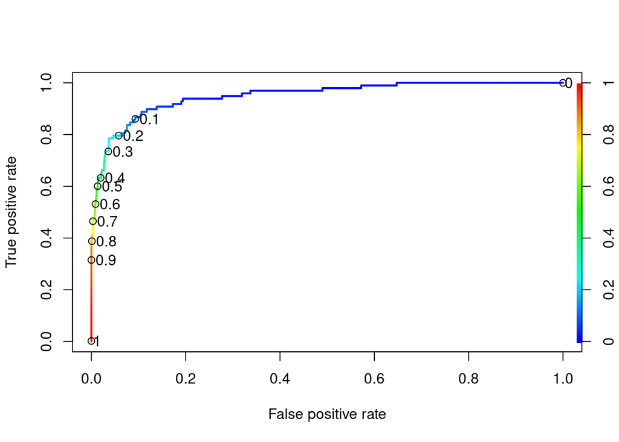

```r
ROCRpred <- prediction(logit.probs, test$Personal.Loan)
ROCRperf <- performance(ROCRpred, measure = "tpr", x.measure = "fpr")
auc.logit <- performance(ROCRpred, measure = "auc")
auc.logit <- auc.logit@y.values[[1]]

plot(ROCRperf, colorize = TRUE, lwd=2, text.adj = c(-0.2,0.5), print.cutoffs.at = seq(0,1,0.1))
```

## Classification Tree

```r
class.tree.model <- rpart(Personal.Loan ~ ., method="class", data=train)
printcp(class.tree.model)
```

```
##
## Classification tree:
## rpart(formula = Personal.Loan ~ ., data = train, method = "class")
##
## Variables actually used in tree construction:
## [1] CCAvg      CD.Account Education  Family     Income
##
## Root node error: 382/4000 = 0.0955
##
## n= 4000
##
##         CP nsplit rel error  xerror     xstd
## 1 0.324607      0   1.00000 1.00000 0.048660
## 2 0.149215      2   0.35079 0.35079 0.029791
## 3 0.015707      3   0.20157 0.20157 0.022749
## 4 0.010000      5   0.17016 0.19372 0.022310
```

Selecting the optimal value for the complexity parameter and perform tuning

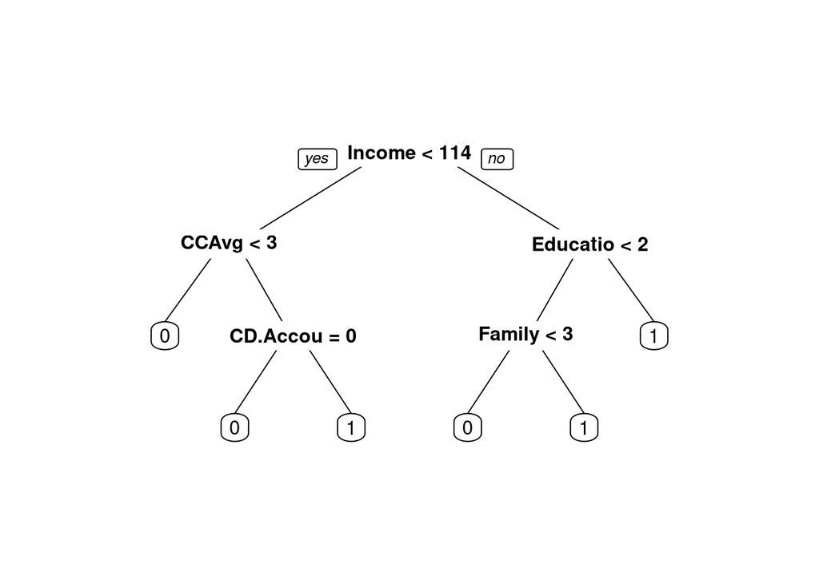

```r
min_ind <- which.min(class.tree.model$cptable[, "xerror"])
min_cp <- class.tree.model$cptable[min_ind, "CP"]
class.tree.model.prune <-prune(class.tree.model, cp = min_cp)
prp(class.tree.model.prune)
```

Prediction performance:

```r
class.tree.model.prune.predictions <- predict(class.tree.model.prune,
                                              newdata=test,type = 'class')
results.class.tree <- confusionMatrix(data = test$Personal.Loan,
                                reference = class.tree.model.prune.predictions,
                                positive = "1")
results.class.tree
```

```
## Confusion Matrix and Statistics
##
##           Reference
## Prediction   0   1
##          0 897   5
##          1  17  81
##
##                Accuracy : 0.978
##                  95% CI : (0.9669, 0.9862)
##     No Information Rate : 0.914
##     P-Value [Acc > NIR] : < 2e-16
##
##                   Kappa : 0.8684
##
##  Mcnemar's Test P-Value : 0.01902
##
##             Sensitivity : 0.9419
##             Specificity : 0.9814
##          Pos Pred Value : 0.8265
##          Neg Pred Value : 0.9945
##              Prevalence : 0.0860
##          Detection Rate : 0.0810
##    Detection Prevalence : 0.0980
##       Balanced Accuracy : 0.9616
##
##        'Positive' Class : 1
##
```

Accuracy quite good as well as Sensitivity and Specificity

The ROC:

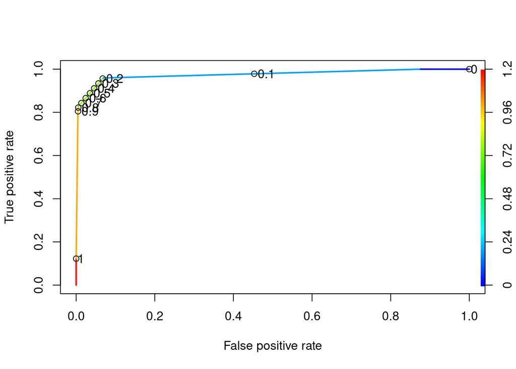

```r
class.tree.pr <- predict(class.tree.model.prune,newdata = test, type = "prob")[, 2]
class.tree.ROCRpred <- prediction(class.tree.pr, test$Personal.Loan)
class.tree.ROCRperf <- performance(class.tree.ROCRpred, measure = "tpr", x.measure = "fpr")
auc.class.tree <- performance(class.tree.ROCRpred, measure = "auc")
auc.class.tree <- auc.class.tree@y.values[[1]]

plot(class.tree.ROCRperf, colorize = TRUE, lwd=2, text.adj = c(-0.2,0.5), print.cutoffs.at = seq(0,1,0.1))
```

The specificity looks really good. We get a sensitivity of over 90% when using a cut-off of 0.2 while maintaining a very high specificity.

## Bagging

```r
bag.model <- randomForest(Personal.Loan ~ ., data = train, mtry=11, importance=T)
bag.model
```

```
##
## Call:
##  randomForest(formula = Personal.Loan ~ ., data = train, mtry = 11,      importance = T)
##                Type of random forest: classification
##                      Number of trees: 500
## No. of variables tried at each split: 11
##
##         OOB estimate of  error rate: 1.25%
## Confusion matrix:
##      0   1 class.error
## 0 3605  13 0.003593145
## 1   37 345 0.096858639
```

Prediction performance:

```r
predict.bag <- predict(bag.model, newdata = test)
results.bag.model <- confusionMatrix(test$Personal.Loan,
                                     predict.bag,positive = "1")
results.bag.model
```

```
## Confusion Matrix and Statistics
##
##           Reference
## Prediction   0   1
##          0 898   4
##          1  13  85
##
##                Accuracy : 0.983
##                  95% CI : (0.9729, 0.9901)
##     No Information Rate : 0.911
##     P-Value [Acc > NIR] : < 2e-16
##
##                   Kappa : 0.8997
##
##  Mcnemar's Test P-Value : 0.05235
##
##             Sensitivity : 0.9551
##             Specificity : 0.9857
##          Pos Pred Value : 0.8673
##          Neg Pred Value : 0.9956
##              Prevalence : 0.0890
##          Detection Rate : 0.0850
##    Detection Prevalence : 0.0980
##       Balanced Accuracy : 0.9704
##
##        'Positive' Class : 1
##
```

Slight improvement compared to Classification tree.

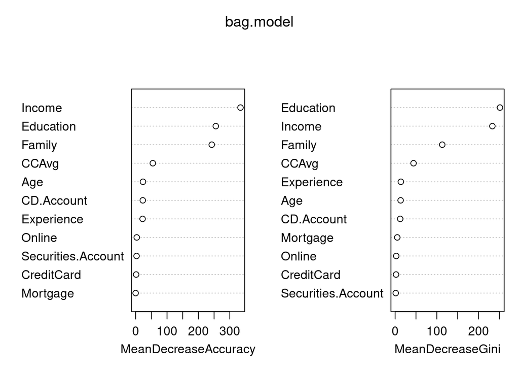

```r
varImpPlot(bag.model)
```

Both the MeanDecreaseAccuracy and MeanDecreaseGini measures indicate that Education, Income, and Family are the most influential variables in the bagging model.

The ROC:

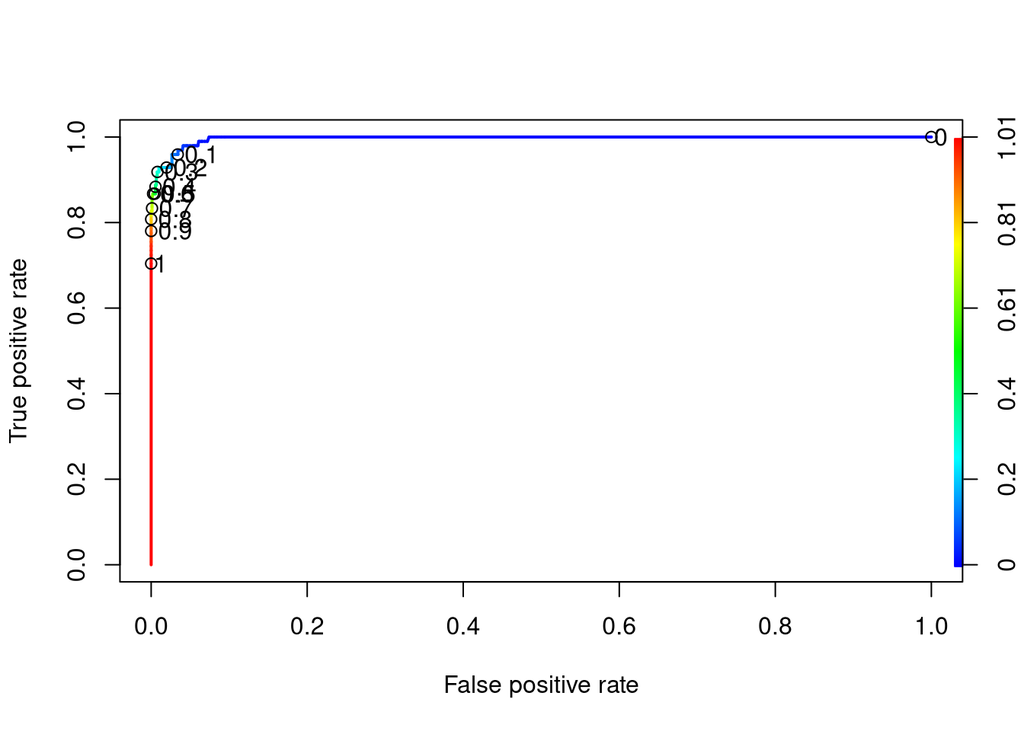

```r
bag.pr <- predict(bag.model,newdata = test, type = "prob")[, 2]
bag.ROCRpred <- prediction(bag.pr, test$Personal.Loan)
bag.ROCRperf <- performance(bag.ROCRpred, measure = "tpr", x.measure = "fpr")
auc.bag <- performance(bag.ROCRpred, measure = "auc")
auc.bag <- auc.bag@y.values[[1]]

plot(bag.ROCRperf, colorize = TRUE, lwd=2, text.adj = c(-0.2,0.5), print.cutoffs.at = seq(0,1,0.1))
```

Slight improvement again.

## Random Forest

```r
forest.model<- randomForest(Personal.Loan ~ ., data = train,
                            mtry=floor((ncol(train) - 1)/3), importance=T)
forest.model
```

```
##
## Call:
##  randomForest(formula = Personal.Loan ~ ., data = train, mtry = floor((ncol(train) -      1)/3), importance = T)
##                Type of random forest: classification
##                      Number of trees: 500
## No. of variables tried at each split: 3
##
##         OOB estimate of  error rate: 1.2%
## Confusion matrix:
##      0   1 class.error
## 0 3611   7 0.001934771
## 1   41 341 0.107329843
```

Prediction performance:

```r
perdict.forest <- predict(forest.model, newdata = test)
results.forest.model <- confusionMatrix(as.factor(test$Personal.Loan),
                                        perdict.forest,positive = "1")
results.forest.model
```

```
## Confusion Matrix and Statistics
##
##           Reference
## Prediction   0   1
##          0 900   2
##          1  14  84
##
##                Accuracy : 0.984
##                  95% CI : (0.9741, 0.9908)
##     No Information Rate : 0.914
##     P-Value [Acc > NIR] : < 2e-16
##
##                   Kappa : 0.9043
##
##  Mcnemar's Test P-Value : 0.00596
##
##             Sensitivity : 0.9767
##             Specificity : 0.9847
##          Pos Pred Value : 0.8571
##          Neg Pred Value : 0.9978
##              Prevalence : 0.0860
##          Detection Rate : 0.0840
##    Detection Prevalence : 0.0980
##       Balanced Accuracy : 0.9807
##
##        'Positive' Class : 1
##
```

Minimal improvement to the bagging model.

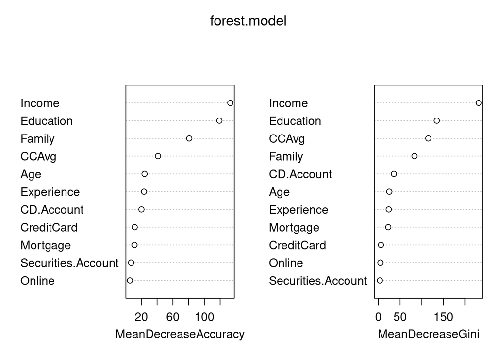

```r
varImpPlot(forest.model)
```

The results are very similar to those from the bagging model. However, in the random forest the variable CCAvg becomes more important than Family according to the MeanDecreaseGini measure. This shift occurs because the random forest algorithm forces each split to consider only a random subset of predictors rather than exposing every tree to the full set of variables.

The ROC:

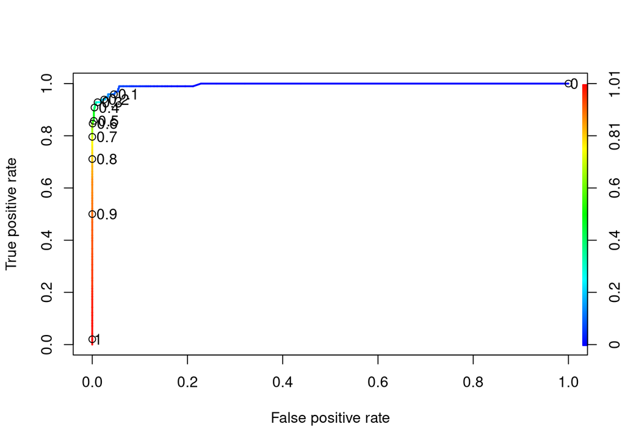

```r
forest.pr <- predict(forest.model,newdata = test, type = "prob")[, 2]
forest.ROCRpred <- prediction(forest.pr, test$Personal.Loan)
forest.ROCRperf <- performance(forest.ROCRpred, measure = "tpr", x.measure = "fpr")
auc.forest <- performance(forest.ROCRpred, measure = "auc")
auc.forest <- auc.forest@y.values[[1]]

plot(forest.ROCRperf, colorize = TRUE, lwd=2, text.adj = c(-0.2,0.5), print.cutoffs.at = seq(0,1,0.1))
```

A even stronger rise to high sensitivity (close to 1) with the FPR staying close to 0

## Linear Discriminant Analysis

```r
# function from exercise solution
transform_numeric <- function(x) {
  # If variable contains nonpositive values → use Yeo–Johnson
  if (any(x <= 0)) {
    pt <- powerTransform(x, family = "yjPower")
    lambda <- pt$lambda
    return(yjPower(x, lambda))
  } else {
    # Otherwise use Box–Cox
    bc <- boxcox(x ~ 1, plotit = F)
    lambda <- bc$x[which.max(bc$y)]
    return((x^lambda - 1) / lambda)
  }
}
```

We have a lot of binary independent variables for which the normality assumption is not met. The only variables that have a continuous distribution are age, income and credit card average score. Let’s have a look at the distributions!

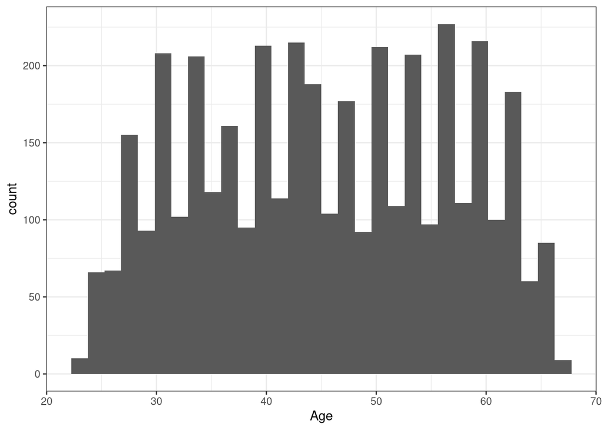

```r
ggplot(data=train, aes(x= Age)) + geom_histogram()
```

Looks ok.

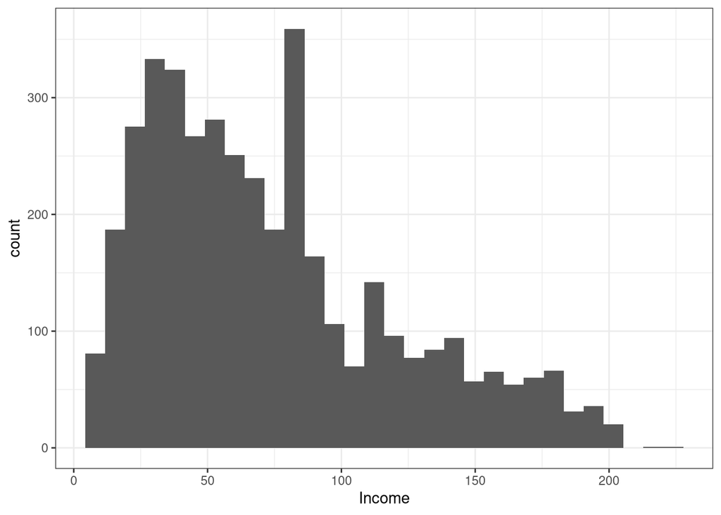

```r
ggplot(data=train, aes(x= Income)) + geom_histogram()
```

Looks somewhat exponentially distributed.

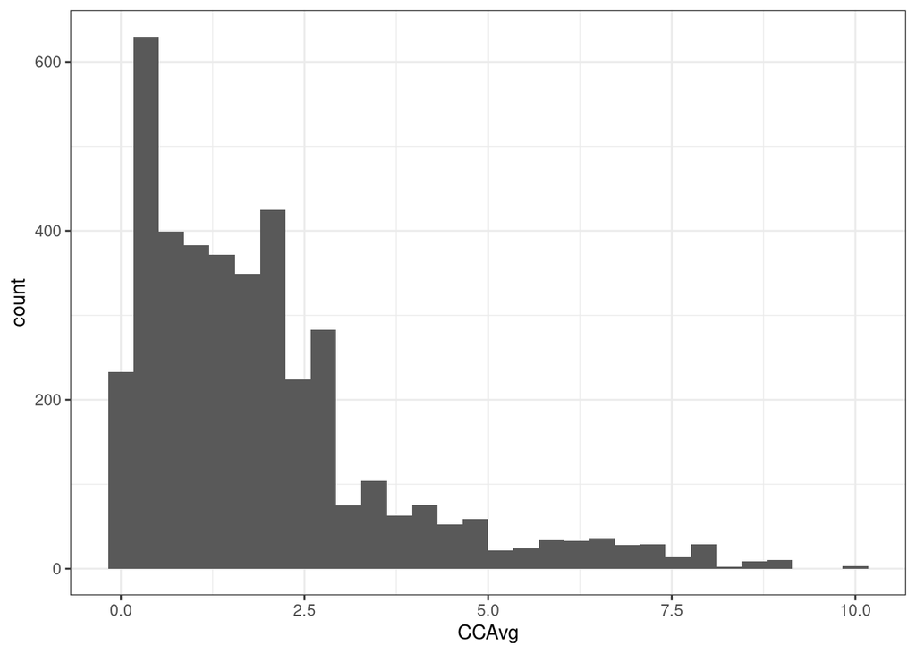

```r
ggplot(data=train, aes(x= CCAvg)) + geom_histogram()
```

Also looks exponentially distributed.

```r
sum(train$CCAvg == 0)
```

```
## [1] 83
```

```r
train.lda <- train %>%
  dplyr::select(c(Personal.Loan, Age,Income,CCAvg)) %>%
  mutate(Income = transform_numeric(Income), CCAvg = transform_numeric(CCAvg))

test.lda <- test %>%
  dplyr::select(c(Personal.Loan, Age,Income,CCAvg)) %>%
  mutate(Income = transform_numeric(Income), CCAvg = transform_numeric(CCAvg))
```

Let’s see what’s changed.

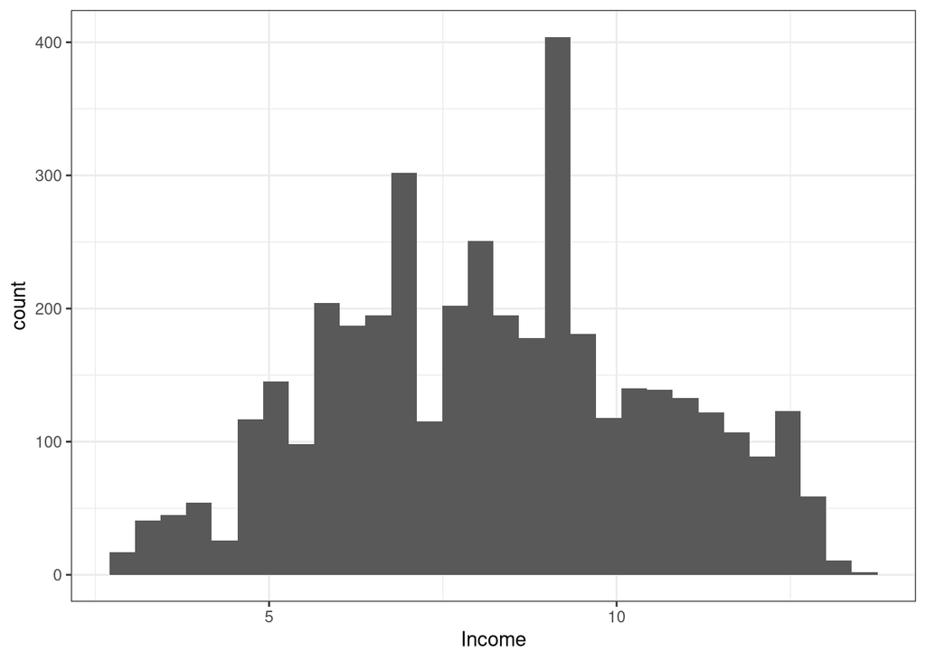

```r
ggplot(data=train.lda, aes(x= Income)) + geom_histogram()
```

Looks much better!

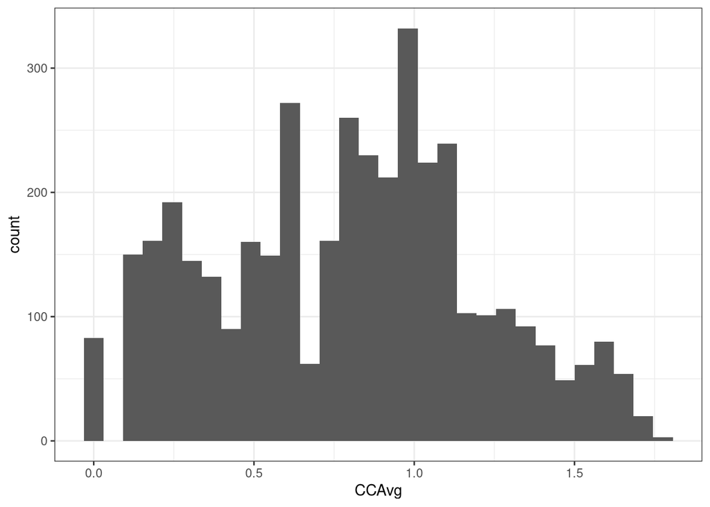

```r
ggplot(data=train.lda, aes(x= CCAvg)) + geom_histogram()
```

Also looks more normally distributed.

Let’s finally normalize the data to have mean 0 and variance 1.

```r
preproc.param.lda <- train.lda %>%
  preProcess(method = c("center", "scale"))

train.lda <- preproc.param.lda %>% predict(train.lda)
test.lda <- preproc.param.lda %>% predict(test.lda)
```

Now we can create the model.

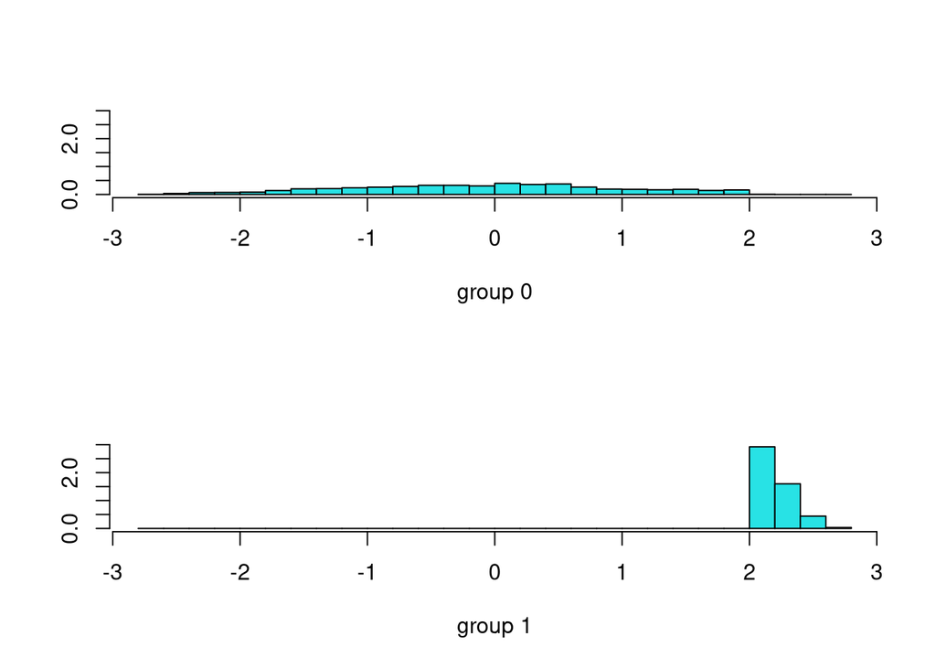

```r
lda.model <- lda(Personal.Loan ~ ., data = train.lda)
predmodel.train.lda <- predict(lda.model, train.lda)

ldahist(predmodel.train.lda$x[,1], g=predmodel.train.lda$class)
```

The distribution in those that are predicted to get a loan doesn’t look normal…

Let’s see how the model performs on the test data.

```r
predmodel.test.lda <- predict(lda.model, newdata=test.lda)
results.lda.model <- confusionMatrix(predmodel.test.lda$class, test.lda$Personal.Loan)
results.lda.model
```

```
## Confusion Matrix and Statistics
##
##           Reference
## Prediction   0   1
##          0 884  77
##          1  18  21
##
##                Accuracy : 0.905
##                  95% CI : (0.8851, 0.9225)
##     No Information Rate : 0.902
##     P-Value [Acc > NIR] : 0.4003
##
##                   Kappa : 0.2656
##
##  Mcnemar's Test P-Value : 2.67e-09
##
##             Sensitivity : 0.9800
##             Specificity : 0.2143
##          Pos Pred Value : 0.9199
##          Neg Pred Value : 0.5385
##              Prevalence : 0.9020
##          Detection Rate : 0.8840
##    Detection Prevalence : 0.9610
##       Balanced Accuracy : 0.5972
##
##        'Positive' Class : 0
##
```

The accuracy is not quite as good compared to the other models but this was to be expected, as we are only using 3 predictors here.

ROC curve:

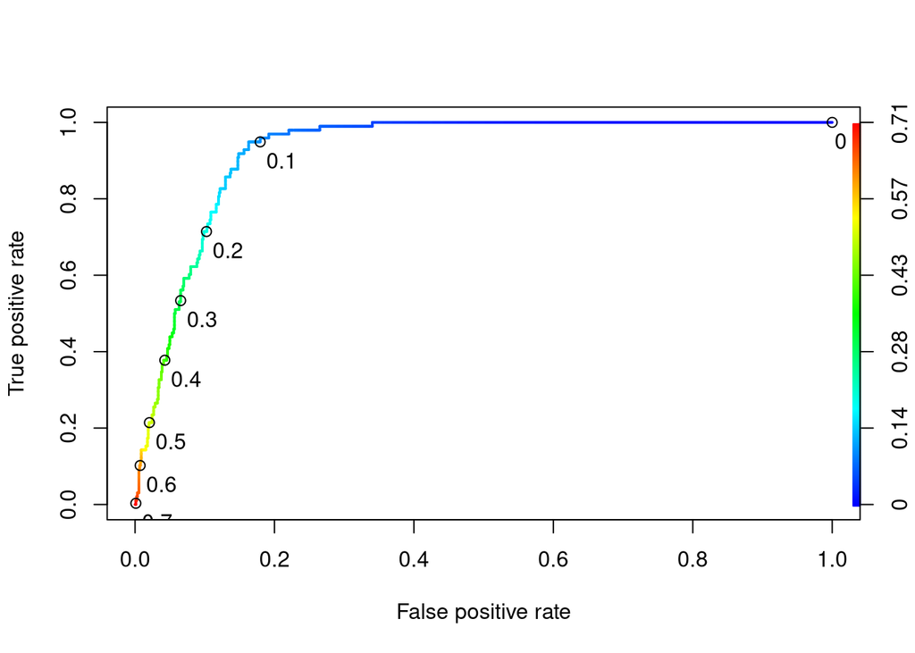

```r
pr.lda <- prediction(predmodel.test.lda$posterior[,2], test.lda$Personal.Loan)
prf.lda <- performance(pr.lda, measure = "tpr", x.measure = "fpr")
auc.lda <- performance(pr.lda, measure = "auc")
auc.lda <- auc.lda@y.values[[1]]

plot(prf.lda, colorize = TRUE, lwd=2, text.adj = c(-0.2,1.7), print.cutoffs.at = seq(0,0.7,0.1))
```

Similar to the other models, we see that the sensitivity only becomes acceptable for quite small cut-off values, i.e. to reach a sensitivity of 0.8 we need a cut-off of lower then 0.2.

## K nearest Neighbours

Let’s try the KNN algorithm.

Here we use the normed (centered and scaled) data. We also included categorical predictors except for the zip code, because it has no order. All other categorical variables are ordinal so it is valid to include them.

```r
knn.model<- knn(train=dplyr::select(train.normed, -c(Personal.Loan)),
                test=dplyr::select(test.normed, -c(Personal.Loan)),
                cl=train.normed$Personal.Loan, k=23,prob=T)
results.knn <- confusionMatrix(knn.model, test.normed$Personal.Loan)
results.knn
```

```
## Confusion Matrix and Statistics
##
##           Reference
## Prediction   0   1
##          0 899  60
##          1   3  38
##
##                Accuracy : 0.937
##                  95% CI : (0.9201, 0.9513)
##     No Information Rate : 0.902
##     P-Value [Acc > NIR] : 5.170e-05
##
##                   Kappa : 0.519
##
##  Mcnemar's Test P-Value : 1.722e-12
##
##             Sensitivity : 0.9967
##             Specificity : 0.3878
##          Pos Pred Value : 0.9374
##          Neg Pred Value : 0.9268
##              Prevalence : 0.9020
##          Detection Rate : 0.8990
##    Detection Prevalence : 0.9590
##       Balanced Accuracy : 0.6922
##
##        'Positive' Class : 0
##
```

Accuracy is better than with LDA.

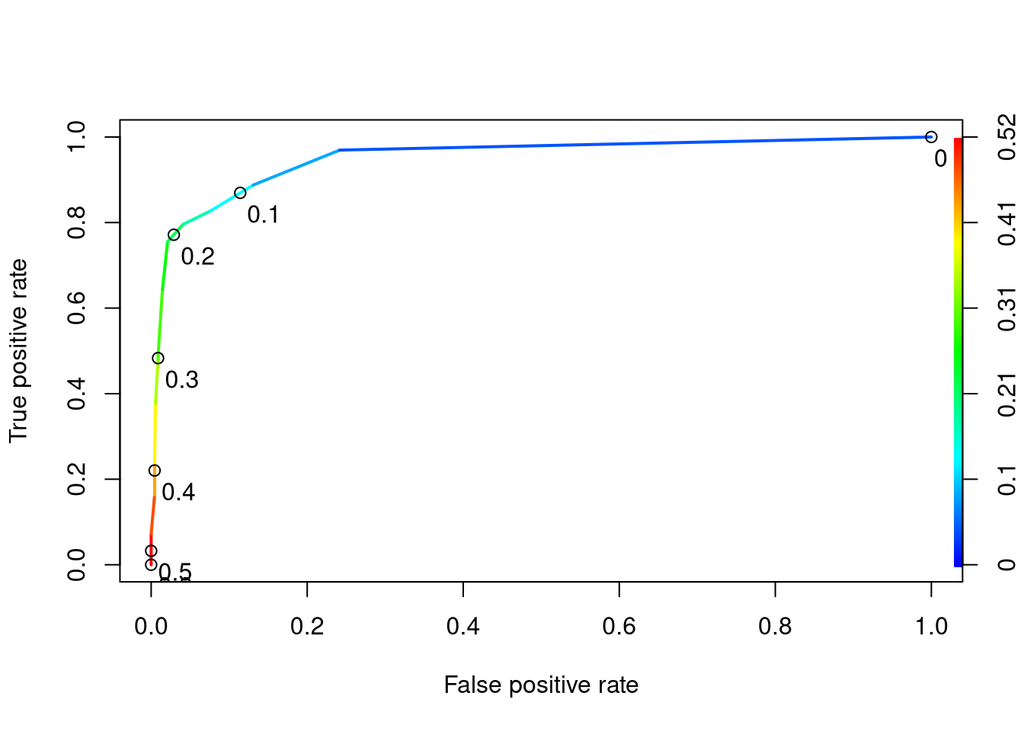

```r
knn.probs <- 1 - attr(knn.model, "prob")
pr.knn <- prediction(knn.probs, test.normed$Personal.Loan)
prf.knn <- performance(pr.knn, measure = "tpr", x.measure = "fpr")
auc.knn <- performance(pr.knn, measure = "auc")
auc.knn <- auc.knn@y.values[[1]]

plot(prf.knn, colorize = TRUE, lwd=2, text.adj = c(-0.2,1.7), print.cutoffs.at = seq(0,0.6,0.1))
```

Here, we need to set the cut-off below 0.2 to get a sensitivity of 0.8.

## Support Vector Classification

```r
svm.linear <- tune.svm(Personal.Loan ~ .,data = train.normed, kernel="linear",
                      cost=c(0.01,0.1,0.2,0.5,0.7,1,2,3,5,10,15,20,50,100), probability=T)
best.linear <-svm.linear$best.model
summary(best.linear)
```

```
##
## Call:
## best.svm(x = Personal.Loan ~ ., data = train.normed, cost = c(0.01,
##     0.1, 0.2, 0.5, 0.7, 1, 2, 3, 5, 10, 15, 20, 50, 100), kernel = "linear",
##     probability = T)
##
##
## Parameters:
##    SVM-Type:  C-classification
##  SVM-Kernel:  linear
##        cost:  5
##
## Number of Support Vectors:  488
##
##  ( 246 242 )
##
##
## Number of Classes:  2
##
## Levels:
##  0 1
```

```r
best.test <- predict(best.linear,newdata=test.normed ,type="class", probability = T)
probs <- attr(best.test, "probabilities")[,2]
results.svc <- confusionMatrix(best.test,test.normed$Personal.Loan)
results.svc
```

```
## Confusion Matrix and Statistics
##
##           Reference
## Prediction   0   1
##          0 893  40
##          1   9  58
##
##                Accuracy : 0.951
##                  95% CI : (0.9357, 0.9635)
##     No Information Rate : 0.902
##     P-Value [Acc > NIR] : 8.710e-09
##
##                   Kappa : 0.6774
##
##  Mcnemar's Test P-Value : 1.822e-05
##
##             Sensitivity : 0.9900
##             Specificity : 0.5918
##          Pos Pred Value : 0.9571
##          Neg Pred Value : 0.8657
##              Prevalence : 0.9020
##          Detection Rate : 0.8930
##    Detection Prevalence : 0.9330
##       Balanced Accuracy : 0.7909
##
##        'Positive' Class : 0
##
```

The accuracy is better than with KNN and LDA.

Let’s look at the ROC curve.

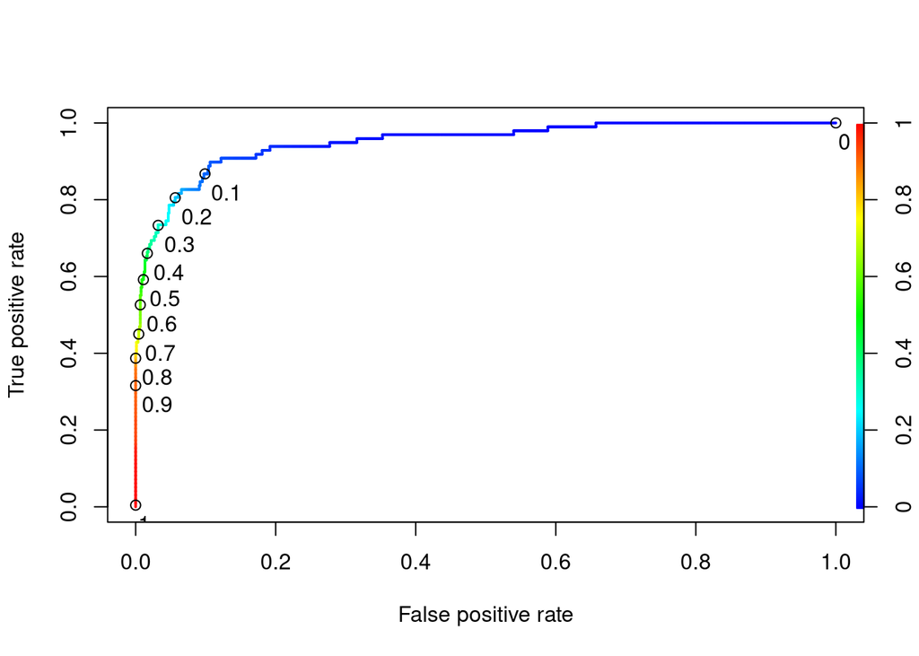

```r
pr.svc.linear <- prediction(probs, test.normed$Personal.Loan)
prf.svc.linear <- performance(pr.svc.linear, measure = "tpr", x.measure = "fpr")
auc.svc.linear <- performance(pr.svc.linear, measure = "auc")
auc.svc.linear <- auc.svc.linear@y.values[[1]]

plot(prf.svc.linear, colorize = TRUE, lwd=2, text.adj = c(-0.2,1.7), print.cutoffs.at = seq(0,1,0.1))
```

With a cut-off of 0.2 we can achieve a sensitivity of just about 0.8, while maintaining a very high specificity.

```r
svm.poly <- tune.svm(Personal.Loan ~ .,data = train.normed, kernel="polynomial", probability=T,
                      cost=c(0.01,0.1,0.2,0.5,0.7,1,2,3,5,10,15,20,50,100))
best.poly <- svm.poly$best.model
summary(best.poly)
```

```
##
## Call:
## best.svm(x = Personal.Loan ~ ., data = train.normed, cost = c(0.01,
##     0.1, 0.2, 0.5, 0.7, 1, 2, 3, 5, 10, 15, 20, 50, 100), kernel = "polynomial",
##     probability = T)
##
##
## Parameters:
##    SVM-Type:  C-classification
##  SVM-Kernel:  polynomial
##        cost:  50
##      degree:  3
##      coef.0:  0
##
## Number of Support Vectors:  234
##
##  ( 134 100 )
##
##
## Number of Classes:  2
##
## Levels:
##  0 1
```

```r
best.poly.test <- predict(best.poly,newdata=test.normed ,type="class",probability =T)
probs.poly <- attr(best.poly.test, "probabilities")[,2]
results.poly <- confusionMatrix(best.poly.test,test.normed$Personal.Loan)
results.poly
```

```
## Confusion Matrix and Statistics
##
##           Reference
## Prediction   0   1
##          0 898  23
##          1   4  75
##
##                Accuracy : 0.973
##                  95% CI : (0.961, 0.9821)
##     No Information Rate : 0.902
##     P-Value [Acc > NIR] : < 2.2e-16
##
##                   Kappa : 0.8328
##
##  Mcnemar's Test P-Value : 0.000532
##
##             Sensitivity : 0.9956
##             Specificity : 0.7653
##          Pos Pred Value : 0.9750
##          Neg Pred Value : 0.9494
##              Prevalence : 0.9020
##          Detection Rate : 0.8980
##    Detection Prevalence : 0.9210
##       Balanced Accuracy : 0.8804
##
##        'Positive' Class : 0
##
```

This model has really high accuracy.

Let’s look at the ROC curve.

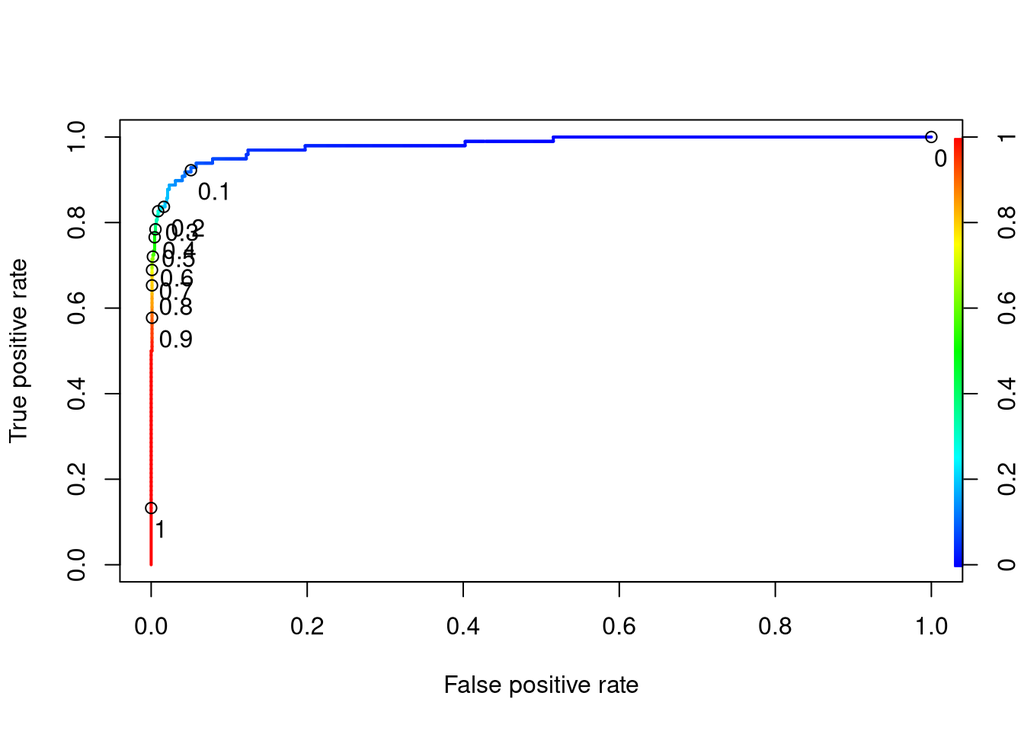

```r
pr.svc.poly <- prediction(probs.poly, test.normed$Personal.Loan)
prf.svc.poly <- performance(pr.svc.poly, measure = "tpr", x.measure = "fpr")
auc.svc.poly <- performance(pr.svc.poly, measure = "auc")
auc.svc.poly <- auc.svc.poly@y.values[[1]]

plot(prf.svc.poly, colorize = TRUE, lwd=2, text.adj = c(-0.2,1.7), print.cutoffs.at = seq(0,1,0.1))
```

Here, the prediction is extremely good. We get a sensitivity of over 90% when using a cut-off of 0.1, while maintaining an extremely high specificity.

# Summary

```r
results.df <- data.frame(
  Model = c("Logistic regression", "Classification Tree", "Bagging",
    "Random Forest" ,"LDA", "kNN", "linear SVC", "poly SVC"),
  Accuracy = c(
    results.logit.model$overall["Accuracy"],
    results.class.tree$overall["Accuracy"],
    results.bag.model$overall["Accuracy"],
    results.forest.model$overall["Accuracy"],
    results.lda.model$overall["Accuracy"],
    results.knn$overall["Accuracy"],
    results.svc$overall["Accuracy"],
    results.poly$overall["Accuracy"]
  ),
  Sensitivity = c(
    results.logit.model$byClass["Sensitivity"],
    results.class.tree$byClass["Sensitivity"],
    results.bag.model$byClass["Sensitivity"],
    results.forest.model$byClass["Sensitivity"],
    results.lda.model$byClass["Sensitivity"],
    results.knn$byClass["Sensitivity"],
    results.svc$byClass["Sensitivity"],
    results.poly$byClass["Sensitivity"]
  ),
  Specificity = c(
    results.logit.model$byClass["Specificity"],
    results.class.tree$byClass["Specificity"],
    results.bag.model$byClass["Specificity"],
    results.forest.model$byClass["Specificity"],
    results.lda.model$byClass["Specificity"],
    results.knn$byClass["Specificity"],
    results.svc$byClass["Specificity"],
    results.poly$byClass["Specificity"]
  ),
  AUC = c(auc.logit, auc.class.tree, auc.bag, auc.forest, auc.lda, auc.knn,
    auc.svc.linear, auc.svc.poly)
)
```

Summary table of model performances sorted by AUC:

```r
results.df %>% arrange(desc(AUC)) %>%
  mutate(across(-Model, round, 3)) %>%
  kable(
    caption = "Classification performance across models",
    align = "lcccc"
  ) %>%
  kable_styling(
    bootstrap_options = c("striped", "hover", "condensed"),
    full_width = FALSE
  )
```

Classification performance across models

| Model | Accuracy | Sensitivity | Specificity | AUC |
| --- | --- | --- | --- | --- |
| Bagging | 0.983 | 0.955 | 0.986 | 0.997 |
| Random Forest | 0.984 | 0.977 | 0.985 | 0.995 |
| poly SVC | 0.973 | 0.996 | 0.765 | 0.981 |
| Classification Tree | 0.978 | 0.942 | 0.981 | 0.974 |
| kNN | 0.937 | 0.997 | 0.388 | 0.951 |
| Logistic regression | 0.948 | 0.592 | 0.987 | 0.950 |
| linear SVC | 0.951 | 0.990 | 0.592 | 0.950 |
| LDA | 0.905 | 0.980 | 0.214 | 0.926 |

While Bagging reduces variance by averaging over multiple decision trees, the trees tend to be highly correlated, which limits the extent of variance reduction. Random Forest addresses this limitation by introducing feature-level randomness at each split, thereby reducing correlation among the trees and improving generalization performance. Given its comparable predictive performance and superior variance reduction properties, Random Forest is selected as the preferred model.